# SPARK SQL (CLOUDS Fall 2018)

In this notebook, we will learn how to use the DataFrame API and SparkSQL to perform simple data analytics tasks.

# Goals

The main goals of this notebook are the following:

1. Understand the advantages and disadvantages of using DataFrame over RDD
2. Analyze the airline data with the DataFrame API and SparkSQL

# Steps

- First, in section 1, we will go through a short introduction about the DataFrame API with a small example to see how can we use it and how it compares to the low-level RDD abstraction.
- In section 2, we delve into the details of the use case of this notebook including: providing the context, introducing the data
- In section 3, we perform data exploration and analysis

# 1. RDD and DataFrame APIs

In our previous notebooks, we have worked with RDDs (Resilient Distributed Dataset), the basic abstraction in Spark. The main reason is due to the task at hand: we have been invovled in the design of distributed algorithms.

In this laboratory session, we study (or revisit) the DataFrame API - an immutable distributed collection of data. DataFrames allow developers to impose a **structure** on a distributed collection of data, allowing higher-level abstraction; in addition, DataFrames provide a domain specific language (DSL) API to manipulate distributed, structured data. Ultimately, the goal is to make Spark accessible to a wider audience, beyond researchers and specialized data engineers.

Let's take a small example to see the difference between RDDs and DataFrames. The two cells below contain short code snippets that perform the same task: count the frequency of words in a document, then sort the result in descending order. The first snippet is the same you have been working on in the very [first notebook](https://github.com/EURECOM-CLOUDS-COURSE/Introduction/blob/master/introduction-lab.ipynb) of the CLOUDS course. The second code snippet uses the DataFrame API.

**Question 1.** Run both approaches (RDD and DataFrame) detailed below, compare their runtime, and discuss. Is the DataFrame API approach faster? Can you explain why?

```python
import time
time_start = time.time()
words = (
            # read the text file
            sc.textFile("/datasets/gutenberg/gutenberg_small.txt").repartition(16)

            # construct words from lines
            .flatMap(lambda line: line.split())

            # map each word to (word, 1)
            .map(lambda x: (x, 1))

            # reduce by key: accumulate sum the freq of the same word
            .reduceByKey(lambda freq1, freq2: freq1 + freq2)

            # swap (word, freq) to (freq, word)
            .map(lambda x: (x[1], x[0]))

            # sort result by key DESC
            .sortByKey(False)
         )
print("Runtime: %.2f sec" % (time.time() - time_start))
print(words.take(5))
```

```
Runtime: 131.44 sec
[(29556020, 'the'), (18043957, 'of'), (14914748, 'and'), (12892052, 'to'), (9779124, 'a')]
```

```python
from pyspark.sql.types import *
from pyspark.sql import SQLContext
from pyspark.sql.functions import explode, split, desc
sqlContext = SQLContext(sc)
time_start = time.time()

# read the text file
df = sqlContext.read.text("/datasets/gutenberg/gutenberg_small.txt")

# show 3 samples
# df.show(3)

result = (
    # split into words
    df.select(explode(split(df.value, "\s+|\t+")).alias('word'))

    # group by each word
    .groupBy(['word'])

    # count the freq
    .count()

    # sort the result
    .orderBy(desc("count"))
)

result.show(5)
print("Runtime: %.2f sec" % (time.time() - time_start))
```

```
+----+--------+
|word|   count|
+----+--------+
| the|29556020|
|  of|18043957|
|    |16611988|
| and|14914748|
|  to|12892052|
+----+--------+
only showing top 5 rows

Runtime: 92.87 sec
```

# 2. Analysis of flight data using the DataFrame API and SparkSQL

## Use case

In this notebook, we play the role of a data scientist working in the travel industry, specifically on air transportation of passengers. We want to explore the data collected by the Department of Transportation (DoT) to understand passengers' behavior, as well as the properties of all flights, across several airline companies.

The dataset provided by the DoT has 29 features, that can be either categorical or numerical. For example, the `src_airport` (source airport) is categorical: there exist no comparison operator between airport names. We can not say "SGN is bigger than NCE". The `departure_time` feature is numerical, for which a comparison operator exists. For instance, "flight departing before 6PM" can be express by "departure_time < 1800".

In this use case, most features are numerical, except carrier, flight_number, cancelled, cancelation_code and diverted. The data contains a header, that is useless when analyzing the data: it serves the purpose of an "embedded schema", to help data scientist figure out what information is available. Note that there are some features with missing values in some lines of the dataset. The missing values are marked by "NA". These values can cause problems when processing the data and can lead to unexpected results. Therefore, we need to remove the header and replace all "NA" values by empty values, such as they can be interpreted as null values.

## DataFrame

As we have seen already, there are multiple ways to manipulate data:

- Using the RDD abstraction
- Using the DataFrame abstraction.

A DataFrame is a distributed collection of data organized into named columns. It is based on the data frame concept in R language or in Pandas for Python. In some sense, it is similar to a table in a relational database: each item is a list of values (the columns). Also, the value in each row of each column can be accessed by the column's name.

To use DataFrames, the data should be clean (no invalid values). That means we cannot create DataFrame directly from the "RAW" data. Instead, we will first create an RDD from RAW data, produce a new, clean RDD, then transform it to a DataFrame and work on it. The RDD `cleaned_data` is an `RDD[String]`. We need to transform it to `RDD[(TypeOfColumn1, TypeOfColumn2, ..., TypeOfColumn29)]` then call a function to create a DataFrame from the new RDD. Please note that, package `com.databricks.spark.csv` can really help us to load the data efficiently without concerns about parsing, conversions, etc... However, the CSV package can have some problems when loading not well-formatted data or the data that has many kinds of missing values. The guidelines defined this notebook are a general way to help you work with any data.

DataFrames can be constructed from a wide array of sources such as: structured data files, tables in Hive, external databases, or existing RDDs.

During the labs in this course, we will mainly work with CSV data files. So, in the next sections, we only focus on constructing dataframes from structured data files directly and from existing RDD.

### Constructing a DataFrame directly from structured data file

To construct DataFrame from a structured file directly, the file type must be supported. Currently, Spark supports csv, json, avro and many more. Among these types, the csv type is one of the most popular in data analytics. A DataFrame is constructed from csv files by using the package spark-csv from Databricks.

```python
from pyspark.sql import SQLContext
from pyspark.sql.types import *

sqlContext = SQLContext(sc)

df = sqlContext.read.load('/datasets/airline/1994.csv',
    format='com.databricks.spark.csv',
    header='true',
    inferSchema='true',
    nullValue='NA'
)
```

Using the function load parametrized with `com.databricks.spark.csv`, we ask the SqlContext to use the parser from the DataBricks package. Additionally, we can specify whether the file has a header, or ask the parser to guess the data type of columns automatically. The parsed data types is viewed using the function printSchema.

```python
# print(df.dtypes)
df.printSchema()
```

```
root
 |-- Year: integer (nullable = true)
 |-- Month: integer (nullable = true)
 |-- DayofMonth: integer (nullable = true)
 |-- DayOfWeek: integer (nullable = true)
 |-- DepTime: integer (nullable = true)
 |-- CRSDepTime: integer (nullable = true)
 |-- ArrTime: integer (nullable = true)
 |-- CRSArrTime: integer (nullable = true)
 |-- UniqueCarrier: string (nullable = true)
 |-- FlightNum: integer (nullable = true)
 |-- TailNum: string (nullable = true)
 |-- ActualElapsedTime: integer (nullable = true)
 |-- CRSElapsedTime: integer (nullable = true)
 |-- AirTime: string (nullable = true)
 |-- ArrDelay: integer (nullable = true)
 |-- DepDelay: integer (nullable = true)
 |-- Origin: string (nullable = true)
 |-- Dest: string (nullable = true)
 |-- Distance: integer (nullable = true)
 |-- TaxiIn: string (nullable = true)
 |-- TaxiOut: string (nullable = true)
 |-- Cancelled: integer (nullable = true)
 |-- CancellationCode: string (nullable = true)
 |-- Diverted: integer (nullable = true)
 |-- CarrierDelay: string (nullable = true)
 |-- WeatherDelay: string (nullable = true)
 |-- NASDelay: string (nullable = true)
 |-- SecurityDelay: string (nullable = true)
 |-- LateAircraftDelay: string (nullable = true)
```

```python
df = (df
          # change type of column CRSDepTime by casting its values to interger type
          .withColumn('CRSDepTime', df.CRSDepTime.cast('int'))

          # rename the column
          .withColumnRenamed('CRSDepTime', 'scheduled_departure_time')
    )

# print schema of the current data
df.printSchema()

# run jobs to calculate basic statistic information and show it
df.describe().show()
```

```
root
 |-- Year: integer (nullable = true)
 |-- Month: integer (nullable = true)
 |-- DayofMonth: integer (nullable = true)
 |-- DayOfWeek: integer (nullable = true)
 |-- DepTime: integer (nullable = true)
 |-- scheduled_departure_time: integer (nullable = true)
 |-- ArrTime: integer (nullable = true)
 |-- CRSArrTime: integer (nullable = true)
 |-- UniqueCarrier: string (nullable = true)
 |-- FlightNum: integer (nullable = true)
 |-- TailNum: string (nullable = true)
 |-- ActualElapsedTime: integer (nullable = true)
 |-- CRSElapsedTime: integer (nullable = true)
 |-- AirTime: string (nullable = true)
 |-- ArrDelay: integer (nullable = true)
 |-- DepDelay: integer (nullable = true)
 |-- Origin: string (nullable = true)
 |-- Dest: string (nullable = true)
 |-- Distance: integer (nullable = true)
 |-- TaxiIn: string (nullable = true)
 |-- TaxiOut: string (nullable = true)
 |-- Cancelled: integer (nullable = true)
 |-- CancellationCode: string (nullable = true)
 |-- Diverted: integer (nullable = true)
 |-- CarrierDelay: string (nullable = true)
 |-- WeatherDelay: string (nullable = true)
 |-- NASDelay: string (nullable = true)
 |-- SecurityDelay: string (nullable = true)
 |-- LateAircraftDelay: string (nullable = true)

+-------+-------+-----------------+------------------+------------------+------------------+------------------------+------------------+-----------------+-------------+-----------------+-------+------------------+------------------+-------+-----------------+------------------+-------+-------+-------…
|summary|   Year|            Month|        DayofMonth|         DayOfWeek|           DepTime|scheduled_departure_time|           ArrTime|       CRSArrTime|UniqueCarrier|        FlightNum|TailNum| ActualElapsedTime|    CRSElapsedTime|AirTime|         ArrDelay|          DepDelay| Origin|   Dest|       …
+-------+-------+-----------------+------------------+------------------+------------------+------------------------+------------------+-----------------+-------------+-----------------+-------+------------------+------------------+-------+-----------------+------------------+-------+-------+-------…
|  count|5180048|          5180048|           5180048|           5180048|           5113308|                 5180048|           5101202|          5180048|      5180048|          5180048|      0|           5101202|           5180048|      0|          5101202|           5113308|5180048|5180048|       …
|   mean| 1994.0|6.579943853802127|15.723382486031017|3.9516016067804776| 1345.266130849149|      1338.6794068317513|1494.4365151585841|1495.874874904634|         null|920.2637743897354|   null|114.00258860558746|114.82526995888841|   null|5.662489742613603|  6.65992152242736|   null|   null|670.740…
| stddev|    0.0|3.436720373974637| 8.788272360339212|1.9902384397190065|470.22426611386146|      463.61750114772104|  483.984955904281|472.6701494862173|         null|608.1342943927972|   null| 64.88861058427706| 64.20406191593874|   null|23.61815604081688|22.226297708488598|   null|   null|522.269…
|    min|   1994|                1|                 1|                 1|                 1|                       1|                 1|                1|           AA|                1|   null|               -40|                -5|   null|             -115|              -109|    ABE|    ABE|       …
|    max|   1994|               12|                31|                 7|              2400|                    2400|              2400|             2400|           WN|             3599|   null|               740|               578|   null|             1313|              1439|    YAK|    YAK|       …
+-------+-------+-----------------+------------------+------------------+------------------+------------------------+------------------+-----------------+-------------+-----------------+-------+------------------+------------------+-------+-----------------+------------------+-------+-------+-------…
```

### Constructing a DataFrame from an existing RDD

Another way to construct a DataFrame is using data from an existing RDD. The main advantage of this approach is that it does not need a third party library. However, with this method, we have to remove the header ourself and provide a clear schema.

```python
from pyspark.sql import SQLContext
from pyspark.sql.types import *
from pyspark.sql.functions import explode, split, desc, col, udf, round
%matplotlib inline
import matplotlib.pyplot as plt
import matplotlib.colors as mcolors
import pandas as pd
import numpy as np
import pyspark.sql.functions as func
import matplotlib.patches as mpatches
import seaborn as sns

sqlContext = SQLContext(sc)

data = sc.textFile('/datasets/airline/1994.csv')

# extract the header
header = data.first()

# replace invalid data with NULL and remove header
cleaned_data = (
        data

        # filter out the header
        .filter(lambda line: line != header)

         # replace the 'missing data' by empty value
        .map(lambda line: ','.join(list(map(lambda x: x if x != 'NA' else '',line.split(',')))))
    )

airline_data_schema = StructType([ \
    #StructField( name, dataType, nullable)
    StructField("year",                     IntegerType(), True), \
    StructField("month",                    IntegerType(), True), \
    StructField("day_of_month",             IntegerType(), True), \
    StructField("day_of_week",              IntegerType(), True), \
    StructField("departure_time",           IntegerType(), True), \
    StructField("scheduled_departure_time", IntegerType(), True), \
    StructField("arrival_time",             IntegerType(), True), \
    StructField("scheduled_arrival_time",   IntegerType(), True), \
    StructField("carrier",                  StringType(),  True), \
    StructField("flight_number",            StringType(),  True), \
    StructField("tail_number",              StringType(),  True), \
    StructField("actual_elapsed_time",      IntegerType(), True), \
    StructField("scheduled_elapsed_time",   IntegerType(), True), \
    StructField("air_time",                 IntegerType(), True), \
    StructField("arrival_delay",            IntegerType(), True), \
    StructField("departure_delay",          IntegerType(), True), \
    StructField("src_airport",              StringType(),  True), \
    StructField("dest_airport",             StringType(),  True), \
    StructField("distance",                 IntegerType(), True), \
    StructField("taxi_in_time",             IntegerType(), True), \
    StructField("taxi_out_time",            IntegerType(), True), \
    StructField("cancelled",                StringType(),  True), \
    StructField("cancellation_code",        StringType(),  True), \
    StructField("diverted",                 StringType(),  True), \
    StructField("carrier_delay",            IntegerType(), True), \
    StructField("weather_delay",            IntegerType(), True), \
    StructField("nas_delay",                IntegerType(), True), \
    StructField("security_delay",           IntegerType(), True), \
    StructField("late_aircraft_delay",      IntegerType(), True)\
])
```

```python
# convert each line into a tuple of features (columns) with the corresponding data type
cleaned_data_to_columns = (
    cleaned_data.map(lambda l: l.split(","))
    .map(lambda cols:
         (
            int(cols[0])  if cols[ 0] else None,
            int(cols[1])  if cols[ 1] else None,
            int(cols[2])  if cols[ 2] else None,
            int(cols[3])  if cols[ 3] else None,
            int(cols[4])  if cols[ 4] else None,
            int(cols[5])  if cols[ 5] else None,
            int(cols[6])  if cols[ 6] else None,
            int(cols[7])  if cols[ 7] else None,
            cols[8]       if cols[ 8] else None,
            cols[9]       if cols[ 9] else None,
            cols[10]      if cols[10] else None,
            int(cols[11]) if cols[11] else None,
            int(cols[12]) if cols[12] else None,
            int(cols[13]) if cols[13] else None,
            int(cols[14]) if cols[14] else None,
            int(cols[15]) if cols[15] else None,
            cols[16]      if cols[16] else None,
            cols[17]      if cols[17] else None,
            int(cols[18]) if cols[18] else None,
            int(cols[19]) if cols[19] else None,
            int(cols[20]) if cols[20] else None,
            cols[21]      if cols[21] else None,
            cols[22]      if cols[22] else None,
            cols[23]      if cols[23] else None,
            int(cols[24]) if cols[24] else None,
            int(cols[25]) if cols[25] else None,
            int(cols[26]) if cols[26] else None,
            int(cols[27]) if cols[27] else None,
            int(cols[28]) if cols[28] else None
         ))
)

# create dataframe
df = sqlContext.createDataFrame(cleaned_data_to_columns, airline_data_schema)\
    .select(['year', 'month', 'day_of_month', 'day_of_week',
            'scheduled_departure_time','scheduled_arrival_time',
            'arrival_delay', 'distance',
            'src_airport', 'dest_airport', 'carrier'])\
    .cache()
```

### Examples

Using the contructed DataFrame, we can answer some simple questions:

- How many night flights do we have in our data?
- How many night flights per unique carrier?

**NOTE:** We define "night" to start at 6pm.

```python
df[df.scheduled_departure_time > 1800].count()
```

```
1078203
```

```python
df[df.scheduled_departure_time > 1800].groupBy(df.carrier).count().orderBy('count', ascending=0).collect()
```

```
[Row(carrier='DL', count=208224),
 Row(carrier='US', count=170397),
 Row(carrier='AA', count=142832),
 Row(carrier='WN', count=124024),
 Row(carrier='UA', count=113640),
 Row(carrier='NW', count=100453),
 Row(carrier='CO', count=94501),
 Row(carrier='TW', count=54771),
 Row(carrier='HP', count=44351),
 Row(carrier='AS', count=25010)]
```

# 3. Data exploration

Next, we will go over a series of simple queries on our data, to perform exploration and compute statistics using the DataFrame API and SparkSQL. These queries directly map to the questions you need to answer.

**NOTE:** finding the right question to ask is difficult! Don't be afraid to complement the questions below, with your own questions that, in your opinion, are valuable ways to inspect data. This can give you extra points!

- Basic queries:
  - How many unique origin airports?
  - How many unique destination airports?
  - How many carriers?
  - How many flights that have a scheduled departure time later than 18h00?
- Statistics on flight volume: this kind of statistics are helpful to reason about delays. Indeed, it is plausible to assume that "*the more flights in an airport, the higher the probability of delay*".
  - How many flights in each month of the year?
  - Is there any relationship between the number of flights and the days of week?
  - How many flights in different days of months and in different hours of days?
  - Which are the top 20 busiest airports (this depends on inbound and outbound traffic)?
  - Which are the top 20 busiest carriers?
- Statistics on the fraction of delayed flights
  - What is the percentage of delayed flights (over total flights) for different hours of the day?
  - Which hours of the day are characterized by the longest flight delay?
  - What are the fluctuation of the percentage of delayed flights over different time granularities?
  - What is the percentage of delayed flights which depart from one of the top 20 busiest airports?
  - What is the percentage of delayed flights which belong to one of the top 20 busiest carriers?

## Question 2: Basic queries

### Question 2.1

How many origin airports? How many destination airports? Discuss the results, indicating any discrepancies or strange facts about the data.

```python
src_airport = df.select('src_airport').distinct()
dest_airport  = df.select('dest_airport').distinct()
Nb_src_airport = src_airport.count()
Nb_dest_airport = dest_airport.count()
print("Number of origion airports is:", Nb_src_airport)
print("Number of destination airports is:", Nb_dest_airport)
```

```
Number of origion airports is: 224
Number of destination airports is: 225
```

### Comment:

- The query issued in 224 origin airports and 225 destination airports and it could be concluded as there is one airport that only receives the arrival trips. Otherwise, it literally makes non-senses in normal air traffic daily operation when an airplane arrives at one airport then they also need to depart from that airport in order to travel to other destinations. We will conduct some further investigations on this unreasonable issue in the below queries.

```python
only_dest = dest_airport.subtract(src_airport)
print("Airports are present in the dataset only as destination airport")
only_dest.show()
```

```
Airports are present in the dataset only as destination airport
+------------+
|dest_airport|
+------------+
|         BFI|
|         GUM|
+------------+
```

### Comment:

- The above result listed out two airports - BFI and GUM - that only have the arrival without departed destinations. It can be consolidated with the previous find-out as it was solely one airport extra in the number of destination airports as there would have one airport that only has departed trips. We will carry another query to verify that point.

```python
only_src = src_airport.subtract(dest_airport)
print("Airports are present in the dataset only as source airport")
only_src.show()
```

```
Airports are present in the dataset only as source airport
+-----------+
|src_airport|
+-----------+
|        SPN|
+-----------+
```

### Comment:

- The latest query resulted in SPN airport is the one that only got departed trips but handled no arrival trip.
- In conclusion, there are would be some missing values in the dataset or the given dataset, which took account only in 1994, still have some other information in other times.

### Question 2.2

How many unique carriers are present in the data?

```python
Nb_carrier = df.select('carrier').distinct().count()
print("Number of unique carriers are present in the data is:", Nb_carrier)
```

```
Number of unique carriers are present in the data is: 10
```

### Question 2.3

- How many night flights (that is, flights departing later than 6pm or earlier than 6am)?
- What is the percentage of night flights over the total volume of flights

**NOTE:** Here we're using a more refined definition of what is a night flight, than in our earlier examples.

```python
# query the number of night filghts and total volumes of flights
Nb_night_flights = df[(df.scheduled_departure_time > 1800) | (df.scheduled_departure_time < 600)].count()
Nb_flights = df.count()

# compute the percentage of night flights and print the results
percentage = (Nb_night_flights/Nb_flights)*100
print("Number of night flights is:", Nb_night_flights)
print("The percentage of night flights over the total volume of flights is %.2f" %percentage)
```

```
Number of night flights is: 1121918
The percentage of night flights over the total volume of flights is 21.66
```

## Question 3: Flight volume statistics

### Question 3.1:

How many flights in each month of the year? Plot the changes over months by a line chart and comment the figure.  
From the result, we can learn the dynamics of flight volume over months. For example, if we only consider flights in 1994 (to start, it's always better to focus on smaller amount of data), we can discuss about which months are most likely to have flights experiencing delays.

```
+-----+------+
|month| count|
+-----+------+
|    1|423861|
|    2|386954|
|    3|435516|
|    4|420995|
|    5|436432|
|    6|426490|
|    7|443736|
|    8|451086|
|    9|430861|
|   10|449369|
|   11|428227|
|   12|446521|
+-----+------+
```

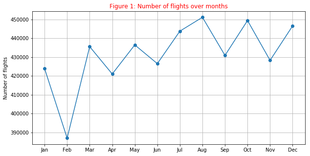

```python
import numpy as np
# labels for months in a year
months_label = ["Jan", "Feb", "Mar", "Apr", "May", "Jun", "Jul", "Aug", "Sep", "Oct", "Nov", "Dec"]

# query the number of flights for each month of the year via 3 steps:
# 1. groupBy: group the dataframe by month
# 2. count: the number of elements in each group (month)
# 3. orderBy: sort the result by month for easily interpret
flights_month = df.groupBy(df.month).count().orderBy(df.month)

# show the query result and do some transformations
flights_month.show()
flights_month = np.array(flights_month.collect())
months = flights_month[:,0]
Nb_flights_month = flights_month[:,1]

# plot the change of flights over months
plt.figure(figsize=(10,5))
plt.plot(months, Nb_flights_month, marker = "o")
plt.xticks(months, months_label)
plt.ylabel("Number of flights")
plt.title('Figure 1: Number of flights over months',fontsize=12, color='r')
plt.grid()
plt.show()
```

### Comment:

- The above illustration showed out the two distinguished season of flights in that year which are the low season from January to June and the high season from July to December. Consequently, the peaked highest sales happened in August - more than 450,000 flights and the lowest was in February, which is less than 390,000 in general.

### Question 3.2:

Is there any relationship between the number of flights and the days of the week? Plot a bar chart and interpret the figure.  
**NOTE:** You should study both global aggregates (irrespectively of the month of the year), and monthly aggregates (day statistics, for each different month of the year).  
By answering this question, we could learn about the importance of the weekend/weekday feature for our predictive task.

```
+-----------+------+
|day_of_week| count|
+-----------+------+
|          1|754636|
|          2|756532|
|          3|756864|
|          4|751537|
|          5|751531|
|          6|695245|
|          7|713703|
+-----------+------+
```

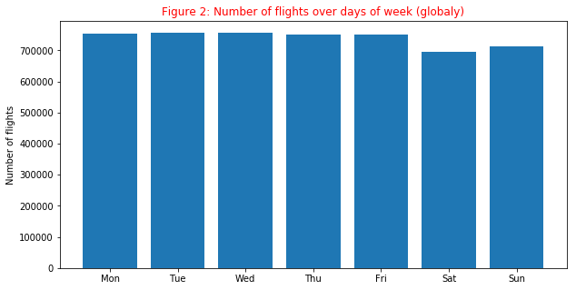

```
+-----+-----------+-----+
|month|day_of_week|count|
+-----+-----------+-----+
|    1|          1|70761|
|    1|          2|56327|
|    1|          3|55944|
|    1|          4|55870|
|    1|          5|56041|
|    1|          6|62488|
|    1|          7|66430|
|    2|          1|56645|
|    2|          2|56549|
|    2|          3|56460|
|    2|          4|56421|
|    2|          5|56823|
|    2|          6|50611|
|    2|          7|53445|
|    3|          1|57356|
|    3|          2|71424|
|    3|          3|71900|
|    3|          4|71942|
|    3|          5|57400|
|    3|          6|51347|
+-----+-----------+-----+
only showing top 20 rows
```

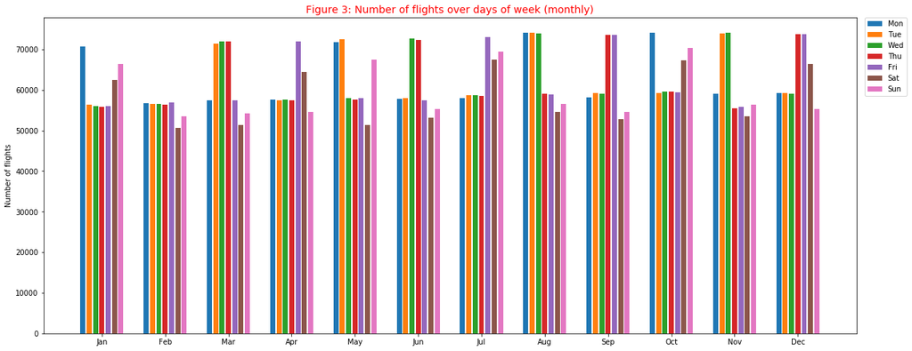

```python
# labels for days of a week
day_of_week_label = ["Mon", "Tue", "Wed", "Thu", "Fri", "Sat", "Sun"]

##****************##
# GLOBAL STATISTIC
##****************##
# query the number of flights for each day of the week (global aggregates) via 3 steps:
# 1. groupBy: group the dataframe by 'day of week'
# 2. count: the number of elements in each group
# 3. orderBy: sort the result by 'day of week' for easily interpret
flights_day_of_week_globaly = df.groupBy(df.day_of_week).count().orderBy(df.day_of_week)

# show the query result and do some transformations
flights_day_of_week_globaly.show()
flights_day_of_week_globaly = np.array(flights_day_of_week_globaly.collect())
day_of_week = flights_day_of_week_globaly[:,0]
Nb_flights_day_of_week_globaly = flights_day_of_week_globaly[:,1]

# plot the change of flights over days of week (globaly)
plt.figure(figsize=(10,5))
plt.bar(day_of_week, Nb_flights_day_of_week_globaly)
plt.xticks(day_of_week, day_of_week_label)
plt.ylabel("Number of flights")
plt.title('Figure 2: Number of flights over days of week (globaly)',fontsize=12, color='r')
plt.show()


##****************##
# MONTHLY STATISTIC
##****************##
# query the number of flights for each day of the week (monthly aggregates) via 3 steps:
# 1. groupBy: group the dataframe by 'day of week' and 'month'
# 2. count: the number of elements in each group
# 3. orderBy: sort the result by 'day of week' and 'month' for easily interpret
flights_day_of_week_monthly = df.groupBy(df.month, df.day_of_week).count().orderBy(df.month, df.day_of_week)

# show the query result and do some transformations
flights_day_of_week_monthly.show()
flights_day_of_week_monthly = np.array(flights_day_of_week_monthly.collect())

# plot the change of flights over days of week (monthly)
pos = list(range(len(months)))
width = 0.1
plt.figure(figsize=(20,8))

for d in range(len(day_of_week)):
    Nb_flights = []
    for m in range(len(months)):
        Nb_flights.append(flights_day_of_week_monthly[m*len(day_of_week)+d][2])
    plt.bar([p + width*d for p in pos], Nb_flights, width-0.02)

plt.xticks([p + 3 * width for p in pos], months_label)
plt.ylabel('Number of flights')
plt.title('Figure 3: Number of flights over days of week (monthly)',fontsize=14, color='r')
plt.legend(day_of_week_label, bbox_to_anchor=(1.01, 1), loc=2, borderaxespad=0.)
plt.show()
```

### Question 3.3

How many flights in different days of months and in different hours of days?  
**NOTE:** Similarly to the previous note, you need to compute both global statistcs and monthly statistics.  
Plot bar charts, and interpret your figures.

```
+------------+------+
|day_of_month| count|
+------------+------+
|           1|169674|
|           2|169829|
|           3|168678|
|           4|169399|
|           5|168423|
|           6|170650|
|           7|172210|
|           8|170674|
|           9|170077|
|          10|170252|
|          11|172362|
|          12|169542|
|          13|171230|
|          14|172081|
|          15|170737|
|          16|169985|
|          17|170132|
|          18|171868|
|          19|169483|
|          20|171142|
+------------+------+
only showing top 20 rows
```

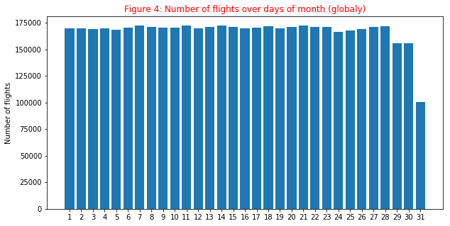

```
+-----+------------+-----+
|month|day_of_month|count|
+-----+------------+-----+
|    1|           1|12158|
|    1|           2|13579|
|    1|           3|14204|
|    1|           4|14183|
|    1|           5|14122|
|    1|           6|14049|
|    1|           7|14072|
|    1|           8|12605|
|    1|           9|13228|
|    1|          10|14122|
|    1|          11|14121|
|    1|          12|14166|
|    1|          13|14062|
|    1|          14|14026|
|    1|          15|12540|
|    1|          16|13013|
|    1|          17|14013|
|    1|          18|13916|
|    1|          19|13776|
|    1|          20|13868|
+-----+------------+-----+
only showing top 20 rows
```

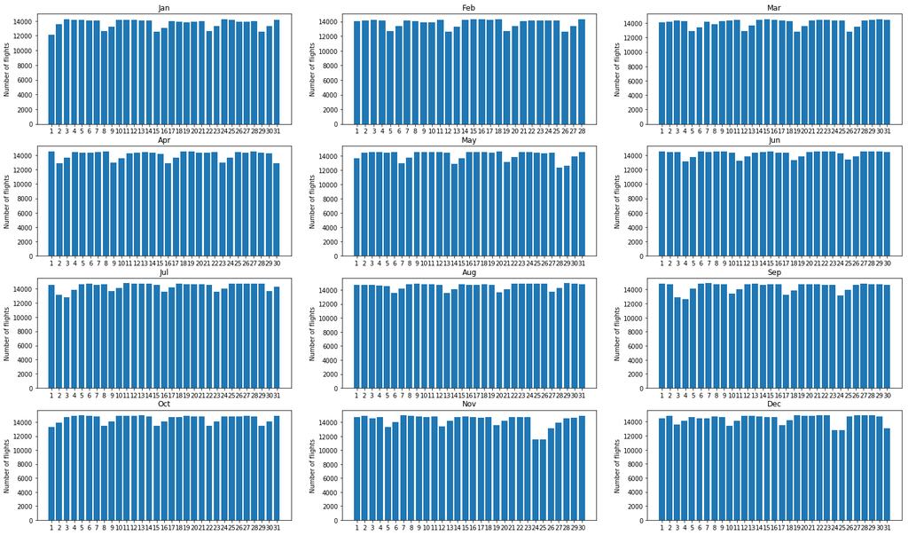

```python
##****************##
# GLOBAL STATISTIC
##****************##
# query the number of flights for each day of the month (global aggregates) via 3 steps:
# 1. groupBy: group the dataframe by 'day of month'
# 2. count: the number of elements in each group
# 3. orderBy: sort the result by 'day of month' for easily interpret
flights_day_of_month_globaly = df.groupBy(df.day_of_month).count().orderBy(df.day_of_month)

# show the query result and do some transformations
flights_day_of_month_globaly.show()
flights_day_of_month_globaly= np.array(flights_day_of_month_globaly.collect())
day_of_month = flights_day_of_month_globaly[:,0]
Nb_flights_day_of_month_globaly = flights_day_of_month_globaly[:,1]

# plot the change of flights over days of month (global)
plt.figure(figsize=(10,5))
plt.bar(day_of_month, Nb_flights_day_of_month_globaly)
plt.xticks(day_of_month, day_of_month)
plt.ylabel("Number of flights")
plt.title('Figure 4: Number of flights over days of month (globaly)',fontsize=12, color='r')
plt.show()


##****************##
# MONTHLY STATISTIC
##****************##
# query the number of flights for each day of the month (month aggregates) via 3 steps:
# 1. groupBy: group the dataframe by 'day of month' and 'month'
# 2. count: the number of elements in each group
# 3. orderBy: sort the result by 'day of month' and 'month' for easily interpret
flights_day_of_month_monthly = df.groupBy(df.month, df.day_of_month).count().orderBy(df.month, df.day_of_month)

# show the query result
flights_day_of_month_monthly.show()

# plot the change of flights over days of month (monthly)
# each bar plot for each month
plt.figure(figsize=(25, 15))
for i in range(len(months)):
    temp = np.array(flights_day_of_month_monthly[df.month == i+1].select('day_of_month', 'count').collect())
    day_of_month = temp[:,0]
    Nb_flights_day_of_month_monthly = temp[:,1]

    plt.subplot(4, 3, i+1)
    plt.bar(day_of_month, Nb_flights_day_of_month_monthly)
    plt.ylabel('Number of flights')
    plt.title(months_label[i])
    plt.xticks(day_of_month, day_of_month)
plt.show()
```

### Comment:

- The two above figures and sub-figures illustrate the flight volumes over the days of the month in two aspects: global aggregate and monthly aggregate
- The first graph demonstrated the number of flights over days of the month of the whole year. The figures have been performed stably from 1st days of the month until the 28th day except for the last three days. It is evident that not every month got the same amount of days such as February only got 28 days in that year and some months have 30 days.
- When looking at the number of flights each day and each month of the year, it reflexed exactly the trend illustrated in question 3.2 when they got a low number of flights during the weekend.
- Additionally, there are also low sales on some holidays such as New Year Eve (31st of December), Thanksgiving and Black Friday (24 and 25 of November) and Christmas Eve and Day (24 and 25 of December).

```
+-----------+------+
|hour_of_day| count|
+-----------+------+
|          0| 13642|
|          1| 12825|
|          2|  2842|
|          3|   564|
|          4|   486|
|          5| 13357|
|          6|257486|
|          7|398796|
|          8|397060|
|          9|341597|
|         10|300375|
|         11|313577|
|         12|356830|
|         13|360762|
|         14|294214|
|         15|313131|
|         16|317809|
|         17|368695|
|         18|338147|
|         19|287033|
+-----------+------+
only showing top 20 rows
```

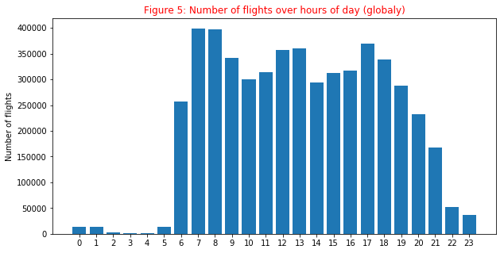

```
+-----+-----------+-----+
|month|hour_of_day|count|
+-----+-----------+-----+
|    1|          0| 1154|
|    1|          1|  901|
|    1|          2|  238|
|    1|          3|   62|
|    1|          4|   33|
|    1|          5| 1017|
|    1|          6|21360|
|    1|          7|31184|
|    1|          8|32814|
|    1|          9|28242|
|    1|         10|24073|
|    1|         11|26409|
|    1|         12|28302|
|    1|         13|30128|
|    1|         14|24179|
|    1|         15|25659|
|    1|         16|26598|
|    1|         17|30522|
|    1|         18|27939|
|    1|         19|23358|
+-----+-----------+-----+
only showing top 20 rows
```

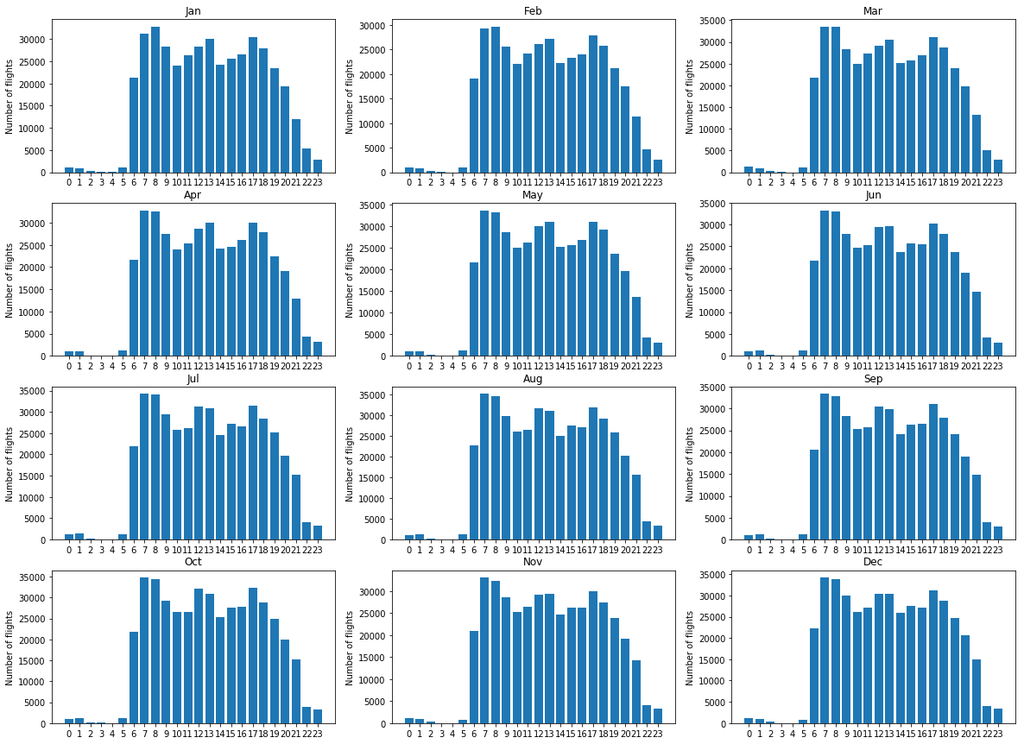

```python
##****************##
# GLOBAL STATISTIC
##****************##
# create a new dataframe which adding the column 'hour_of_day' to the old one.
# the 'hour_of_day' is computed using the data of "scheduled_departure_time" column
# (which consist of hour and minitue values i.e:1830) divide into 100 to get only the 'hour' value
# in case of flight at 24h, change it into 0h by take the remainder of the previous result divide by 24
df_hour_of_day = df.withColumn('hour_of_day', ((df.scheduled_departure_time/100).cast('int'))%24)

# query the number of flights for each hour of day (global aggregates) via 3 steps:
# 1. groupBy: group the dataframe by 'hour_of_day'
# 2. count: the number of elements in each group
# 3. orderBy: sort the result by 'hour_of_day' for easily interpret
flights_hour_of_day_globaly = df_hour_of_day.groupBy('hour_of_day').count().orderBy('hour_of_day')

# show the query result
flights_hour_of_day_globaly.show()
flights_hour_of_day_globaly= np.array(flights_hour_of_day_globaly.collect())
hour_of_day = flights_hour_of_day_globaly[:,0]
Nb_flights_hour_of_day_globaly = flights_hour_of_day_globaly[:,1]

# plot the change of flights over hours of day (global)
plt.figure(figsize=(10,5))
plt.bar(hour_of_day, Nb_flights_hour_of_day_globaly)
plt.xticks(hour_of_day, hour_of_day)
plt.ylabel("Number of flights")
plt.title('Figure 5: Number of flights over hours of day (globaly)',fontsize=12, color='r')
plt.show()


##****************##
# MONTHLY STATISTIC
##****************##
# query the number of flights for each hour of day (month aggregates) via 3 steps:
# 1. groupBy: group the dataframe by 'hour_of_day' and 'month'
# 2. count: the number of elements in each group
# 3. orderBy: sort the result by 'hour_of_day' and 'month' for easily interpret
flights_hour_of_day_monthly = df_hour_of_day.groupBy(df.month, 'hour_of_day').count().orderBy(df.month, 'hour_of_day')

# show the query result
flights_hour_of_day_monthly.show()

# plot the change of flights over hours of day (monthly)
# each bar plot for each month
plt.figure(figsize=(20, 15))
for i in range(len(months)):
    temp = np.array(flights_hour_of_day_monthly[df.month == i+1].select('hour_of_day', 'count').collect())
    hour_of_day = temp[:,0]
    Nb_flights_hour_of_day_monthly = temp[:,1]

    plt.subplot(4, 3, i+1)
    plt.bar(hour_of_day, Nb_flights_hour_of_day_monthly)
    plt.ylabel('Number of flights')
    plt.title(months_label[i])
    plt.xticks(hour_of_day, hour_of_day)
plt.show()
```

### Question 3.4

Which are the **top 20** busiest airports? Compute this in terms of the inbound, outbound and total number of flights.

```
Top 20 busiest airports in term of inbound are:  ['ORD' 'DFW' 'ATL' 'LAX' 'STL' 'DEN' 'PHX' 'DTW' 'PIT' 'CLT' 'MSP' 'SFO'
 'EWR' 'IAH' 'LGA' 'BOS' 'LAS' 'PHL' 'DCA' 'MCO']
```

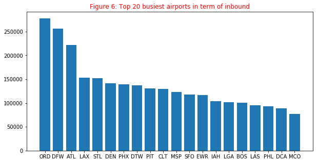

```
Top 20 busiest airports in term of outbound are:  ['ORD' 'DFW' 'ATL' 'LAX' 'STL' 'DEN' 'PHX' 'DTW' 'PIT' 'CLT' 'MSP' 'SFO'
 'EWR' 'IAH' 'LGA' 'BOS' 'LAS' 'PHL' 'DCA' 'MCO']
```

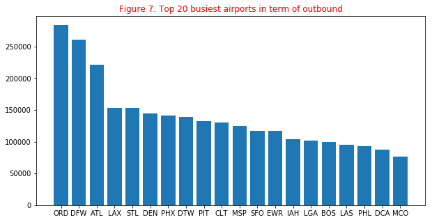

```
Top 20 busiest airports in term of total number of flights are:  ['ORD', 'DFW', 'ATL', 'LAX', 'STL', 'DEN', 'PHX', 'DTW', 'PIT', 'CLT', 'MSP', 'SFO', 'EWR', 'IAH', 'LGA', 'BOS', 'LAS', 'PHL', 'DCA', 'MCO']
```

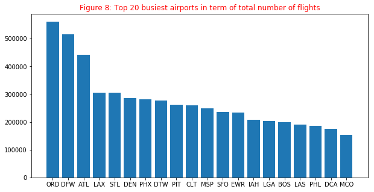

```python
##****************##
# INBOUND STATISTIC
##****************##
# query the top 20 busiest airport in term of inbound via 4 steps:
# 1. groupBy: group the dataframe by 'src_airport' (inbound)
# 2. count: the number of elements in each group
# 3. orderBy: sort the result by 'count' value ascendingly
# 4. take: get the first 20 values presenting for top 20.
airport_inbound = df.groupBy(df.src_airport).count().orderBy('count', ascending=0)
top_busiest_airport_inbound = airport_inbound.take(20)

# print the locations of top 20 busiest airport in term of inbound
top_busiest_airport_inbound_location =  np.array(top_busiest_airport_inbound)[:,0]
print("Top 20 busiest airports in term of inbound are: ", top_busiest_airport_inbound_location)

# plot the locations and filght volumes of top 20 busiest airport in term of inbound
plt.figure(figsize=(10,5))
plt.bar(top_busiest_airport_inbound_location, [x[1] for x in top_busiest_airport_inbound])
plt.title('Figure 6: Top 20 busiest airports in term of inbound',fontsize=12, color='r')
plt.show()


##****************##
# OUTBOUND STATISTIC
##****************##
# query the top 20 busiest airport in term of outbound via 4 steps:
# 1. groupBy: group the dataframe by 'des_airport' (outbound)
# 2. count: the number of elements in each group
# 3. orderBy: sort the result by 'count' value ascendingly
# 4. take: get the first 20 values presenting for top 20.
airport_outbound = df.groupBy(df.dest_airport).count().orderBy('count', ascending=0)
top_busiest_airport_outbound = airport_outbound.take(20)

# print the locations of top 20 busiest airport in term of outbound
top_busiest_airport_outbound_location =  np.array(top_busiest_airport_outbound)[:,0]
print("Top 20 busiest airports in term of outbound are: ", top_busiest_airport_outbound_location)

# plot the locations and filght volumes of top 20 busiest airport in term of outbound
plt.figure(figsize=(10,5))
plt.bar(top_busiest_airport_outbound_location, [x[1] for x in top_busiest_airport_outbound])
plt.title('Figure 7: Top 20 busiest airports in term of outbound',fontsize=12, color='r')
plt.show()


##****************##
# GLOBAL STATISTIC
##****************##
# for analyzing the total number of flights create a new dataframe which
# adding the column 'airport' to the old one. The 'airport' is computed
# using the data of "src_airport" union with "dest_airport" columns.
df_airport = df.withColumn('airport', df.src_airport).union(df.withColumn('airport', df.dest_airport))

# query the top 20 busiest airport in term of total number of flights via 4 steps:
# 1. groupBy: group the dataframe by 'airport'
# 2. count: the number of elements in each group
# 3. orderBy: sort the result by 'count' value ascendingly
# 4. take: get the first 20 values presenting for top 20.
airport = df_airport.groupBy('airport').count().orderBy('count', ascending=0)
top_busiest_airport = airport.take(20)

# print the locations of top 20 busiest airport in term of total number of flights
top_busiest_airport_location =  np.array(top_busiest_airport)[:,0].tolist()
print("Top 20 busiest airports in term of total number of flights are: ", top_busiest_airport_location)

# plot the locations and filght volumes of top 20 busiest airport in term of total number of flights
plt.figure(figsize=(10,5))
plt.bar(top_busiest_airport_location, [x[1] for x in top_busiest_airport])
plt.title('Figure 8: Top 20 busiest airports in term of total number of flights',fontsize=12, color='r')
plt.show()
```

### Comment:

- In general, the order top 20 aiports have remained unchanged in the above three aspects such as inbound, outbound and total number of flights. The ORD, DFW and ATL have been always returned outstanding number of flights compared with the rest.

### Question 3.5

Which are the **top 20** busiest carriers? Compute this in terms of number of flights.

```
Top busiest carriers  ['DL', 'US', 'AA', 'UA', 'WN', 'CO', 'NW', 'TW', 'HP', 'AS']
```

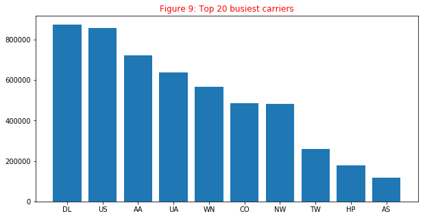

```python
# query the top 20 busiest carriers via 4 steps:
# 1. groupBy: group the dataframe by 'carrier'
# 2. count: the number of elements in each group
# 3. orderBy: sort the result by 'count' value ascendingly
# 4. take: get the first 20 values presenting for top 20.
carriers = df.groupby(df.carrier).count().orderBy('count', ascending=0)
top_busiest_carriers = carriers.take(20)

# print the locations of top 20 busiest carriers
top_busiest_carrier_location =  np.array(top_busiest_carriers)[:,0].tolist()
print("Top busiest carriers ", top_busiest_carrier_location)

# plot the locations and filght volumes of top 20 busiest carriers
plt.figure(figsize=(10,5))
plt.bar(top_busiest_carrier_location, [x[1] for x in top_busiest_carriers])
plt.title('Figure 9: Top 20 busiest carriers',fontsize=12, color='r')
plt.show()
```

## Question 4

In this series of questions we focus on the computation of statistics about the percentage of delayed flights.

### Question 4.1

What is the percentage of delayed flights for different hours of the day? Plot a bar chart and interpret the figure.

IMPORTANT!

A flight is considered as delayed if it's actual arrival time is more than 15 minutes later than the scheduled arrival time.

```
+-----------+------------------+
|hour_of_day|    ratio_of_delay|
+-----------+------------------+
|          0| 17.09426770268289|
|          1|14.838206627680313|
|          2| 5.348346235045742|
|          3|1.5957446808510638|
|          4|   5.1440329218107|
|          5| 6.094182825484765|
|          6| 8.068399835330853|
|          7|10.564549293373053|
|          8|13.353901173626152|
|          9| 14.67870033987418|
|         10|13.552392842280483|
|         11|14.784247569177586|
|         12|15.775859653056077|
|         13|16.822448040536422|
|         14|17.263964325287034|
|         15| 19.96640383737158|
|         16|20.660837169494886|
|         17|22.946880212641886|
|         18|22.302134870337458|
|         19|23.267011110220775|
+-----------+------------------+
only showing top 20 rows
```

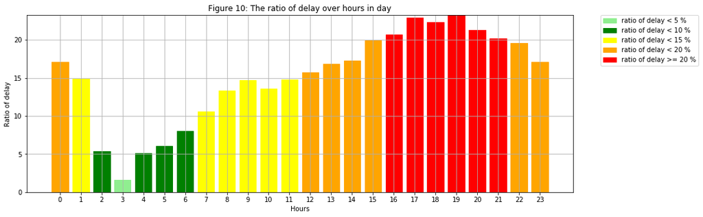

```
+-----+-----------+------------------+
|month|hour_of_day|    ratio_of_delay|
+-----+-----------+------------------+
|    1|          0|21.143847487001732|
|    1|          1| 20.42175360710322|
|    1|          2| 5.042016806722689|
|    1|          3| 3.225806451612903|
|    1|          4|3.0303030303030303|
|    1|          5|  9.04621435594887|
|    1|          6| 13.98876404494382|
|    1|          7|17.268471010774757|
|    1|          8| 21.45425732918876|
|    1|          9|22.923305714892713|
|    1|         10|21.339259751588916|
|    1|         11|22.666515203150443|
|    1|         12|24.425835629990814|
|    1|         13| 24.33284652150823|
|    1|         14| 23.95467140907399|
|    1|         15| 27.80700728789119|
|    1|         16|28.705165801939994|
|    1|         17|30.859707751785596|
|    1|         18| 29.12774258205376|
|    1|         19|29.651511259525645|
+-----+-----------+------------------+
only showing top 20 rows
```

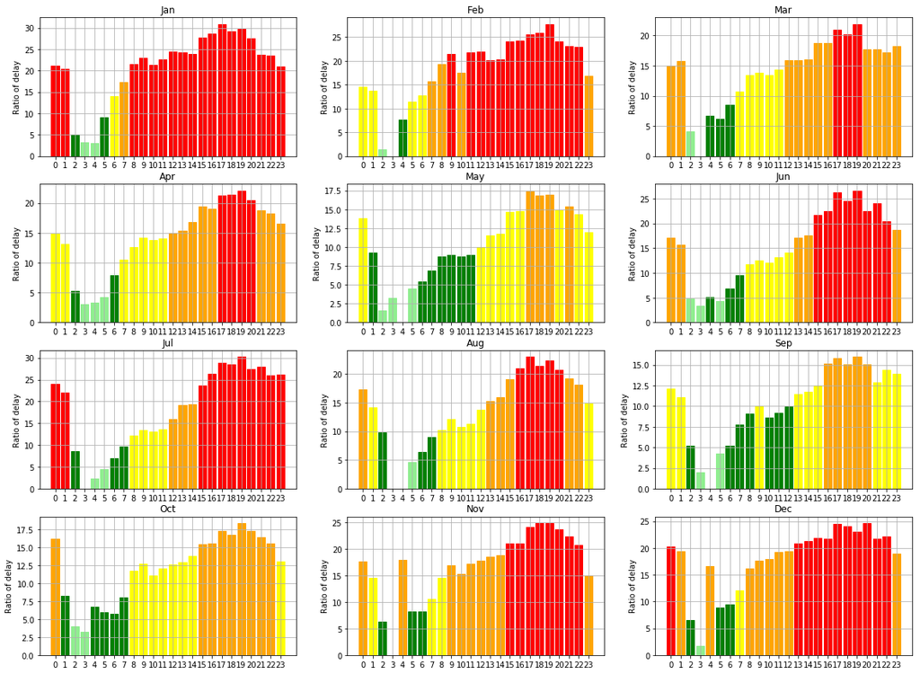

```python
##****************##
# GLOBAL STATISTIC
##****************##
# for analyzing the delayed flights, create a new dataframe which
# adding the column 'is_delayed' to the old one. The 'is_delayed' is computed
# using the data of "arrival_delay" column. The value of the 'is_delayed' column
# will be 1 (delayed) if the arrival delay is more than 15 minutes and 0 in others cases.
df_with_delay = df_hour_of_day.withColumn('is_delayed', func.when(df["arrival_delay"] >= 15, 1).otherwise(0))

# query percentage of delayed flights for different hours of the day via 3 steps:
# 1. groupBy: group the dataframe by 'hour_of_day'
# 2. agg: compute percentage of delayed flights over the total of fights for each group
# 3. orderBy: sort the result by 'hour_of_day' values
delay_ratio_per_hour = df_with_delay.groupBy('hour_of_day')\
                                    .agg((100*func.sum('is_delayed')/func.count('*'))\
                                    .alias('ratio_of_delay')).orderBy('hour_of_day')

# show the percentage of delayed flights for different hours of the day
delay_ratio_per_hour .show()

# plot the percentage of delayed flights for different hours of the day
pdf_delay_ratio_per_hour = pd.DataFrame(data=delay_ratio_per_hour.collect())
plt.figure(figsize=(15, 5))
plt.xlabel("Hours")
plt.ylabel("Ratio of delay")
plt.title('Figure 10: The ratio of delay over hours in day')
plt.grid(True,which="both",ls="-")
bars = plt.bar(pdf_delay_ratio_per_hour[0], pdf_delay_ratio_per_hour[1], align='center', edgecolor = "black")
plt.xticks(pdf_delay_ratio_per_hour[0], pdf_delay_ratio_per_hour[0])
for i in range(0, len(bars)):
    color = 'red'
    if pdf_delay_ratio_per_hour[1][i] < 5:
        color = 'lightgreen'
    elif pdf_delay_ratio_per_hour[1][i] < 10:
        color = 'green'
    elif pdf_delay_ratio_per_hour[1][i] < 15:
        color = 'yellow'
    elif pdf_delay_ratio_per_hour[1][i] < 20:
        color = 'orange'

    bars[i].set_color(color)

patch1 = mpatches.Patch(color='lightgreen', label='ratio of delay < 5 %')
patch2 = mpatches.Patch(color='green', label='ratio of delay < 10 %')
patch3 = mpatches.Patch(color='yellow', label='ratio of delay < 15 %')
patch4 = mpatches.Patch(color='orange', label='ratio of delay < 20 %')
patch5 = mpatches.Patch(color='red', label='ratio of delay >= 20 %')

plt.legend(handles=[patch1, patch2, patch3, patch4, patch5], bbox_to_anchor=(1.05, 1), loc=2, borderaxespad=0.)
plt.margins(0.05, 0)
plt.show()



##****************##
# MONTHLY STATISTIC
##****************##
# query percentage of delayed flights for different hours of the day (month aggregates) via 3 steps:
# 1. groupBy: group the dataframe by 'hour_of_day' and 'month'
# 2. agg: compute percentage of delayed flights over the total of fights for each group
# 3. orderBy: sort the result by 'hour_of_day' and 'month' values
delay_ratio_per_hour_monthly = df_with_delay.groupBy(df.month, 'hour_of_day')\
                                    .agg((100*func.sum('is_delayed')/func.count('*'))\
                                    .alias('ratio_of_delay')).orderBy(df.month, 'hour_of_day')

# show the percentage of delayed flights for different hours of the day (monthly)
delay_ratio_per_hour_monthly .show()

# plot the percentage of delayed flights for different hours of the day (monthly)
# each bar plot for each month
plt.figure(figsize=(20, 15))
for i in range(len(months)):
    temp = np.array(delay_ratio_per_hour_monthly[df.month == i+1].select('hour_of_day', 'ratio_of_delay').collect())
    hour_of_day = temp[:,0]
    delay_ratio_per_hour_each_month = temp[:,1]

    plt.subplot(4, 3, i+1)
    bars = plt.bar(hour_of_day, delay_ratio_per_hour_each_month)
    for j in range(0, len(bars)):
        color = 'red'
        if delay_ratio_per_hour_each_month[j] < 5:
            color = 'lightgreen'
        elif delay_ratio_per_hour_each_month[j] < 10:
            color = 'green'
        elif delay_ratio_per_hour_each_month[j] < 15:
            color = 'yellow'
        elif delay_ratio_per_hour_each_month[j] < 20:
            color = 'orange'

        bars[j].set_color(color)
    plt.ylabel('Ratio of delay')
    plt.title(months_label[i])
    plt.xticks(hour_of_day, hour_of_day.astype(int))
    plt.grid(True,which="both",ls="-")

plt.show()
```

### Comment:

- The two above figures and sub-figures illustrate the delay percentage of flights over hours of the days in two aspects: global aggregate and monthly aggregate
- In general, the highest delay times have always been from 4 PM to 9 PM and the lowest delay times are from 2 AM to 6 AM. The first reason that caused the delay due to the high amount of flights which normally peak at 6-7 AM and 5-6 PM. However, the delay is also due to the accumulated of late times of flights, which means the current flight delaying is due to the late arrival of the previous flight. Consequently, the flights happened in the morning are normally on time but the flights of later in the day almost delayed.
- Moreover, moving to the details of delayed times in each month, there are various unexplained issues. First of all, for all the highest number of flights as for August and October but all the trips resulted in high efficiency whenever they got very low delaying ratios, especially October. This issue can have a considerable reason as all the Carriers got the historical performance from previous so they have a plan to reduce the delaying ratio.
- However, January and February have the highest delay ratios in overall 24 hours throughout the month even the flights carried in those months are lowest. The possible reason for this issue as all the Air Carriers plan to reduce the number of flights due to the low seasonal demand for saving operational costs then they accept the high delaying ratios.

### Question 4.2

You will realize that saying *"at 4 A.M. there is a very low chance of a flight being delayed"* is not giving you a full picture of the situation. Indeed, it might be true that there is very little probability for an early flight to be delayed, but if it does, the delay might be huge, like 6 hours!

Then, the question is: **which hours of the day are characterized by the largest mean delay?** (you can consider the median too) Plot a Bar chart and explain it.

With data of year 1994, the flight from 3AM to 4AM often depart earlier than in their schedule. The flights in the morning have less delay then in the afternoon and evening.

So, an attentive student should notice here that we have somehow a problem with the definition of delay! Next, we will improve how to represent and visualize data to overcome this problem.

**NOTE**: the following piece of code assumes you correctly answered the previous questions. The naming convention of the DataFrames we use next should be clear enough for you to produce them by answering the questions above.

```
+-----------+-------------------+
|hour_of_day| avg(arrival_delay)|
+-----------+-------------------+
|          0|  4.631536068730559|
|          1| 2.7302062017944277|
|          2|-2.7850566572237963|
|          3|-2.7652329749103943|
|          4|0.29583333333333334|
|          5|0.26633813495072023|
|          6| 0.6106762748130248|
|          7| 1.7366349096338727|
|          8|  2.807898359028414|
|          9| 3.4053052919247278|
|         10|   3.44393544676388|
|         11|  4.090233343140837|
|         12|  4.496245367107028|
|         13|  5.230250273257823|
|         14|  5.889517094356155|
|         15|  7.594280213778955|
|         16|  8.184353093179144|
|         17|  9.476074194526362|
|         18|  9.354247292912708|
|         19|  9.966784652413988|
+-----------+-------------------+
only showing top 20 rows
```

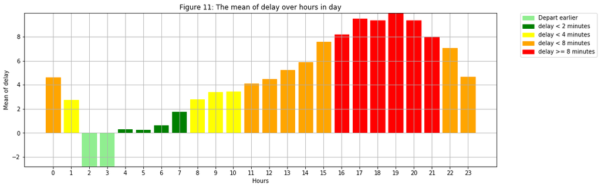

```
+-----+-----------+-------------------+
|month|hour_of_day| avg(arrival_delay)|
+-----+-----------+-------------------+
|    1|          0|  6.415026833631485|
|    1|          1|  7.117715617715618|
|    1|          2| -3.625531914893617|
|    1|          3|-3.1333333333333333|
|    1|          4|-2.6666666666666665|
|    1|          5| 1.7713097713097714|
|    1|          6|   4.59252893898802|
|    1|          7|  6.011113016635226|
|    1|          8|  8.370988612836438|
|    1|          9|  8.673068317422434|
|    1|         10|  8.868493150684932|
|    1|         11|  9.248729351969505|
|    1|         12| 10.287326453337293|
|    1|         13| 10.682596464418435|
|    1|         14| 10.925561005251964|
|    1|         15|  13.10922072623419|
|    1|         16|  14.23614133660428|
|    1|         17| 15.379452244276921|
|    1|         18|  14.25485610832422|
|    1|         19| 14.024683572812036|
+-----+-----------+-------------------+
only showing top 20 rows
```

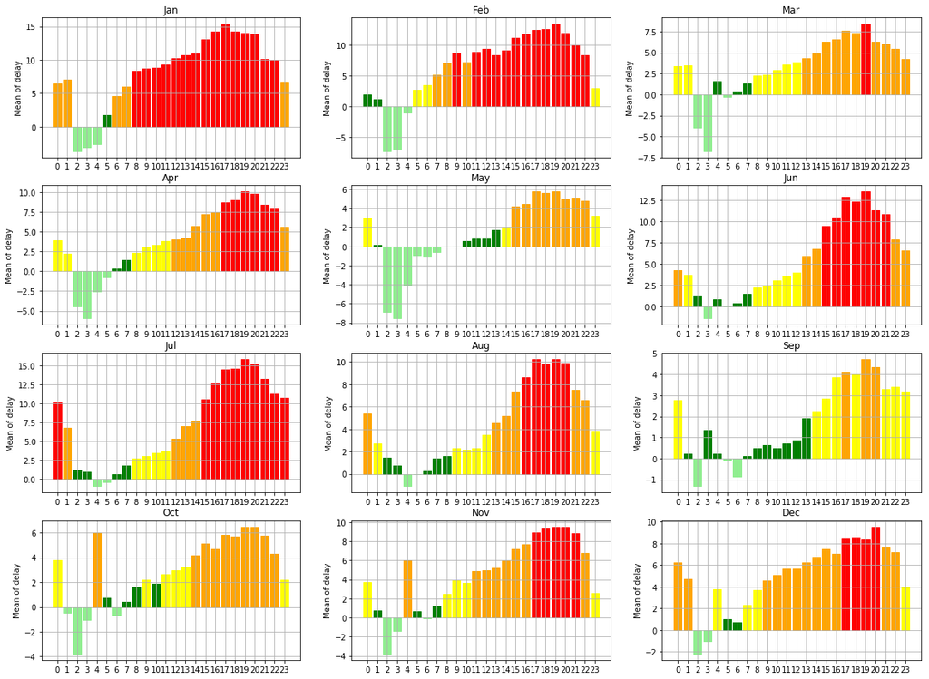

```python
##****************##
# GLOBAL STATISTIC
##****************##
# query mean value of delayed flights for different hours of the day via 3 steps:
# 1. groupBy: group the dataframe by 'hour_of_day'
# 2. avg: compute the average (mean) value of delayed flights for each group
# 3. orderBy: sort the result by 'hour_of_day' values
mean_of_delay_per_hour = df_with_delay.groupBy('hour_of_day').avg('arrival_delay').orderBy('hour_of_day')

# show the mean value of delayed flights for different hours of the day
mean_of_delay_per_hour.show()

# plot the mean value of delayed flights for different hours of the day
pdf_mean_delay_per_hour = pd.DataFrame(data=mean_of_delay_per_hour.collect())
plt.figure(figsize=(15, 5))
plt.xlabel("Hours")
plt.ylabel("Mean of delay")
plt.title('Figure 11: The mean of delay over hours in day')
plt.grid(True,which="both",ls="-")
bars = plt.bar(pdf_mean_delay_per_hour[0], pdf_mean_delay_per_hour[1], align='center', edgecolor = "black")
plt.xticks(pdf_mean_delay_per_hour[0], pdf_mean_delay_per_hour[0])
for i in range(0, len(bars)):
    color = 'red'
    if pdf_mean_delay_per_hour[1][i] < 0:
        color = 'lightgreen'
    elif pdf_mean_delay_per_hour[1][i] < 2:
        color = 'green'
    elif pdf_mean_delay_per_hour[1][i] < 4:
        color = 'yellow'
    elif pdf_mean_delay_per_hour[1][i] < 8:
        color = 'orange'

    bars[i].set_color(color)

patch1 = mpatches.Patch(color='lightgreen', label='Depart earlier')
patch2 = mpatches.Patch(color='green', label='delay < 2 minutes')
patch3 = mpatches.Patch(color='yellow', label='delay < 4 minutes')
patch4 = mpatches.Patch(color='orange', label='delay < 8 minutes')
patch5 = mpatches.Patch(color='red', label='delay >= 8 minutes')

plt.legend(handles=[patch1, patch2, patch3, patch4, patch5], bbox_to_anchor=(1.05, 1), loc=2, borderaxespad=0.)
plt.margins(0.05, 0)
plt.show()


##****************##
# MONTHLY STATISTIC
##****************##
# query mean value of delayed flights for each hour of day (month aggregates) via 3 steps:
# 1. groupBy: group the dataframe by 'hour_of_day' and 'month'
# 2. avg: compute the average (mean) value of delayed flights for each group
# 3. orderBy: sort the result by 'hour_of_day' and 'month' for easily interpret
mean_of_delay_per_hour_monthly = df_with_delay.groupBy(df.month, 'hour_of_day').avg('arrival_delay').orderBy(df.month, 'hour_of_day')

# show the mean value of delayed flights for different hours of the day (monthly)
mean_of_delay_per_hour_monthly.show()

# plot the mean value of delayed flights over hours of day (monthly)
# each bar plot for each month
plt.figure(figsize=(20, 15))
for i in range(len(months)):
    temp = np.array(mean_of_delay_per_hour_monthly[df.month == i+1].select('hour_of_day', 'avg(arrival_delay)').collect())
    hour_of_day = temp[:,0]
    mean_of_delay_per_hour_each_month = temp[:,1]

    plt.subplot(4, 3, i+1)
    bars = plt.bar(hour_of_day, mean_of_delay_per_hour_each_month)
    for j in range(0, len(bars)):
        color = 'red'
        if mean_of_delay_per_hour_each_month[j] < 0:
            color = 'lightgreen'
        elif mean_of_delay_per_hour_each_month[j] < 2:
            color = 'green'
        elif mean_of_delay_per_hour_each_month[j] < 4:
            color = 'yellow'
        elif mean_of_delay_per_hour_each_month[j] < 8:
            color = 'orange'

        bars[j].set_color(color)
    plt.ylabel('Mean of delay')
    plt.title(months_label[i])
    plt.xticks(hour_of_day, hour_of_day.astype(int))
    plt.grid(True,which="both",ls="-")

plt.show()
```

### Question 4.3

Plot a bar chart to show the percentage of delayed flights over days in a month. Discuss your findings from the figure.

```
+------------+------------------+
|day_of_month|    ratio_of_delay|
+------------+------------------+
|           1|14.879121138182633|
|           2|15.071630875763267|
|           3|14.854337850816348|
|           4|14.438692082007568|
|           5| 16.99233477612915|
|           6| 16.37503662467038|
|           7|16.580918645839382|
|           8|16.666861970774693|
|           9|18.872040311153185|
|          10|18.175997932476566|
|          11|14.892493705109015|
|          12| 16.77401469842281|
|          13|17.829819540968288|
|          14| 16.84439304746021|
|          15|17.487129327562275|
|          16|17.532135188398975|
|          17|16.995039146074813|
|          18| 17.34179719319478|
|          19|14.538331278063287|
|          20| 17.57137347933295|
+------------+------------------+
only showing top 20 rows
```

[figure not shown]

```
+-----+------------+------------------+
|month|day_of_month|    ratio_of_delay|
+-----+------------+------------------+
|    1|           1|12.148379667708504|
|    1|           2|24.957655202886812|
|    1|           3|31.695297099408617|
|    1|           4|25.347246703800323|
|    1|           5| 32.09177170372468|
|    1|           6|31.660616413979643|
|    1|           7|24.381750994883458|
|    1|           8|16.342721142403807|
|    1|           9|19.655276685817963|
|    1|          10|19.565217391304348|
|    1|          11|20.041073578358475|
|    1|          12| 30.39672455174361|
|    1|          13| 25.43734888351586|
|    1|          14| 25.95180379295594|
|    1|          15|13.062200956937799|
|    1|          16| 27.64158918005072|
|    1|          17|30.650110611574966|
|    1|          18|  27.3498131647025|
|    1|          19|28.578687572590013|
|    1|          20|30.206230170175946|
+-----+------------+------------------+
only showing top 20 rows
```

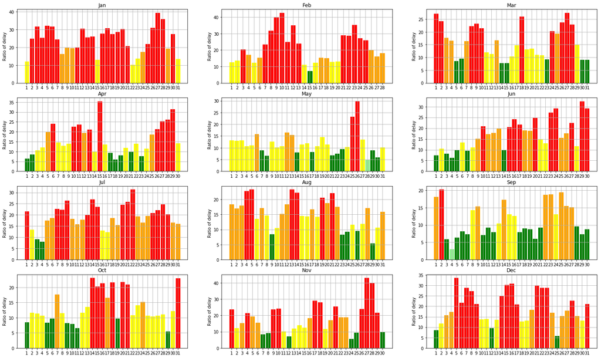

```python
##****************##
# GLOBAL STATISTIC
##****************##
# query percentage of delayed flights for different days of the month via 3 steps:
# 1. groupBy: group the dataframe by 'day_of_month'
# 2. agg: compute percentage of delayed flights over the total of fights for each group
# 3. orderBy: sort the result by 'day_of_month' values
delay_ratio_per_day_of_month = df_with_delay.groupBy('day_of_month')\
                                       .agg((100*func.sum('is_delayed')/func.count('*'))\
                                       .alias('ratio_of_delay')).orderBy('day_of_month')

# show the percentage value of delayed flights for different days of the month
delay_ratio_per_day_of_month.show()

# plot the percentage of delayed flights for different days of the month
pdf_delay_ratio_per_day_of_month = pd.DataFrame(data=delay_ratio_per_day_of_month.collect())
plt.figure(figsize=(15, 5))
plt.xlabel("Hours")
plt.ylabel("Ratio of delay")
plt.title('Figure 12: The ratio of delay over days in month')
plt.grid(True,which="both",ls="-")
bars = plt.bar(pdf_delay_ratio_per_day_of_month[0], pdf_delay_ratio_per_day_of_month[1], align='center', edgecolor = "black")
plt.xticks(pdf_delay_ratio_per_day_of_month[0], pdf_delay_ratio_per_day_of_month[0])
for i in range(0, len(bars)):
    color = 'red'
    if pdf_delay_ratio_per_day_of_month[1][i] < 8:
        color = 'lightgreen'
    elif pdf_delay_ratio_per_day_of_month[1][i] < 15:
        color = 'green'
    elif pdf_delay_ratio_per_day_of_month[1][i] < 20:
        color = 'yellow'
    elif pdf_delay_ratio_per_day_of_month[1][i] < 25:
        color = 'orange'

    bars[i].set_color(color)

patch1 = mpatches.Patch(color='lightgreen', label='ratio of delay < 5 %')
patch2 = mpatches.Patch(color='green', label='ratio of delay < 10 %')
patch3 = mpatches.Patch(color='yellow', label='ratio of delay < 15 %')
patch4 = mpatches.Patch(color='orange', label='ratio of delay < 20 %')
patch5 = mpatches.Patch(color='red', label='ratio of delay >= 20 %')

plt.legend(handles=[patch1, patch2, patch3, patch4, patch5], bbox_to_anchor=(1.05, 1), loc=2, borderaxespad=0.)
plt.margins(0.05, 0)
plt.show()


##****************##
# MONTHLY STATISTIC
##****************##
# query percentage of delayed flights for different days of the month (month aggregates) via 3 steps:
# 1. groupBy: group the dataframe by 'day_of_month' and 'month'
# 2. agg: compute percentage of delayed flights over the total of fights for each group
# 3. orderBy: sort the result by 'day_of_month' and 'month' values
delay_ratio_per_day_of_month_monthly = df_with_delay.groupBy(df.month, 'day_of_month')\
                                       .agg((100*func.sum('is_delayed')/func.count('*'))\
                                       .alias('ratio_of_delay')).orderBy(df.month, 'day_of_month')

# show the percentage value of delayed flights for different days of the month (monthly)
delay_ratio_per_day_of_month_monthly.show()

# plot the percentage of delayed flights for different days of the month (monthly)
# each bar plot for each month
plt.figure(figsize=(25, 15))
for i in range(len(months)):
    temp = np.array(delay_ratio_per_day_of_month_monthly[df.month == i+1].select(df.day_of_month, 'ratio_of_delay').collect())
    day_of_month = temp[:,0]
    delay_ratio_per_day_of_month_each_month = temp[:,1]

    plt.subplot(4, 3, i+1)
    bars = plt.bar(day_of_month, delay_ratio_per_day_of_month_each_month)
    for j in range(0, len(bars)):
        color = 'red'
        if delay_ratio_per_day_of_month_each_month[j] < 5:
            color = 'lightgreen'
        elif delay_ratio_per_day_of_month_each_month[j] < 10:
            color = 'green'
        elif delay_ratio_per_day_of_month_each_month[j] < 15:
            color = 'yellow'
        elif delay_ratio_per_day_of_month_each_month[j] < 20:
            color = 'orange'

        bars[j].set_color(color)
    plt.ylabel('Ratio of delay')
    plt.title(months_label[i])
    plt.xticks(day_of_month, day_of_month.astype(int))
    plt.grid(True,which="both",ls="-")

plt.show()
```

### Question 4.4

Plot a bar chart to show the percentage of delayed flights over days in a week. Discuss your findings from the figure.

```
+-----------+------------------+
|day_of_week|    ratio_of_delay|
+-----------+------------------+
|          1|16.329197122851284|
|          2|15.330349542385518|
|          3|18.151213428039913|
|          4|19.779731403776527|
|          5|19.487020495495194|
|          6|14.140914353932786|
|          7|15.609574290706359|
+-----------+------------------+
```

[figure not shown]

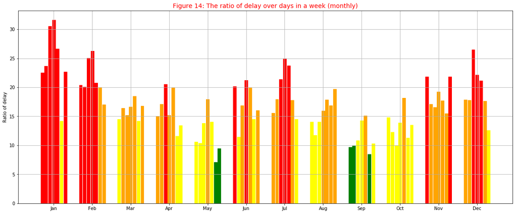

```python
##****************##
# GLOBAL STATISTIC
##****************##
# query percentage of delayed flights for different days of the week via 3 steps:
# 1. groupBy: group the dataframe by 'day_of_week'
# 2. agg: compute percentage of delayed flights over the total of fights for each group
# 3. orderBy: sort the result by 'day_of_week' values
delay_ratio_per_day_of_week = df_with_delay.groupBy('day_of_week')\
                                       .agg((100*func.sum('is_delayed')/func.count('*'))\
                                       .alias('ratio_of_delay')).orderBy('day_of_week')

# show the percentage of delayed flights for different days of the week
delay_ratio_per_day_of_week.show()

# plot the percentage of delayed flights for different days of the week
pdf_delay_ratio_per_day_of_week = pd.DataFrame(data=delay_ratio_per_day_of_week.collect())
plt.figure(figsize=(12,5))
plt.ylabel("Ratio of delay")
plt.title('Figure 13: The ratio of delay over days in a week')
plt.grid(True,which="both",ls="-")
plt.xticks(day_of_week, day_of_week_label)
bars = plt.bar(pdf_delay_ratio_per_day_of_week [0], pdf_delay_ratio_per_day_of_week [1], align='center', edgecolor = "black")
for i in range(0, len(bars)):
    color = 'red'
    if pdf_delay_ratio_per_day_of_week [1][i] < 8:
        color = 'lightgreen'
    elif pdf_delay_ratio_per_day_of_week [1][i] < 15:
        color = 'green'
    elif pdf_delay_ratio_per_day_of_week [1][i] < 20:
        color = 'yellow'
    elif pdf_delay_ratio_per_day_of_week [1][i] < 25:
        color = 'orange'

    bars[i].set_color(color)

patch1 = mpatches.Patch(color='lightgreen', label='ratio of delay < 5 %')
patch2 = mpatches.Patch(color='green', label='ratio of delay < 10 %')
patch3 = mpatches.Patch(color='yellow', label='ratio of delay < 15 %')
patch4 = mpatches.Patch(color='orange', label='ratio of delay < 20 %')
patch5 = mpatches.Patch(color='red', label='ratio of delay >= 20 %')

plt.legend(handles=[patch1, patch2, patch3, patch4, patch5], bbox_to_anchor=(1.05, 1), loc=2, borderaxespad=0.)
plt.margins(0.05, 0)
plt.show()


##****************##
# MONTHLY STATISTIC
##****************##
# query percentage of delayed flights for different days of the week (month aggregates) via 3 steps:
# 1. groupBy: group the dataframe by 'day_of_week' and 'month'
# 2. agg: the number of elements in each group
# 3. orderBy: sort the result by 'day_of_week' and 'month' for easily interpret
delay_ratio_per_day_of_week_monthly = df_with_delay.groupBy(df.month, 'day_of_week')\
                                       .agg((100*func.sum('is_delayed')/func.count('*'))\
                                       .alias('ratio_of_delay')).orderBy(df.month, 'day_of_week').collect()


# plot the change of flights over days of week (monthly)
pos = list(range(len(months)))
width = 0.1
plt.figure(figsize=(20,8))

for d in range(len(day_of_week)):
    delay_ratio = []
    for m in range(len(months)):
        delay_ratio.append(delay_ratio_per_day_of_week_monthly[m*len(day_of_week)+d][2])
    bars = plt.bar([p + width*d for p in pos], delay_ratio, width-0.02)

    for j in range(0, len(bars)):
        color = 'red'
        if delay_ratio[j] < 5:
            color = 'lightgreen'
        elif delay_ratio[j] < 10:
            color = 'green'
        elif delay_ratio[j] < 15:
            color = 'yellow'
        elif delay_ratio[j] < 20:
            color = 'orange'

        bars[j].set_color(color)

plt.xticks([p + 3 * width for p in pos], months_label)
plt.ylabel('Ratio of delay')
plt.title('Figure 14: The ratio of delay over days in a week (monthly)',fontsize=14, color='r')
plt.grid(True,which="both",ls="-")
plt.show()
```

### Question 4.5

Plot a bar chart to show the percentage of delayed flights over months in a year. Discuss your findings from the figure.

```
+-----+------------------+
|month|    ratio_of_delay|
+-----+------------------+
|    1|24.275411042771097|
|    2| 21.42347669232002|
|    3| 16.04280898979601|
|    4| 16.18879084074633|
|    5|11.835291637643437|
|    6|17.327956106825482|
|    7|19.398696522256476|
|    8|15.460023144145461|
|    9|11.516243057505784|
|   10|13.426382327218834|
|   11| 18.42947782367763|
|   12| 19.56167795019719|
+-----+------------------+
```

[figure not shown]

```python
# query percentage of delayed flights for different months of the year via 3 steps:
# 1. groupBy: group the dataframe by 'month'
# 2. agg: compute percentage of delayed flights over the total of fights for each group
# 3. orderBy: sort the result by 'month' values
delay_ratio_per_month = df_with_delay.groupBy('month')\
                                       .agg((100*func.sum('is_delayed')/func.count('*'))\
                                       .alias('ratio_of_delay')).orderBy('month')

# show the percentage of delayed flights for different months of the year
delay_ratio_per_month.show()

# plot the percentage of delayed flights for different months of the year
pdf_delay_ratio_per_month = pd.DataFrame(data=delay_ratio_per_month.collect())
plt.xlabel("Month")
plt.ylabel("Ratio of delay")
plt.title('Figure 15: The ratio of delay over months in a year')
plt.grid(True,which="both",ls="-")
bars = plt.bar(pdf_delay_ratio_per_month[0], pdf_delay_ratio_per_month[1], align='center', edgecolor = "black")
plt.xticks(pdf_delay_ratio_per_month[0], pdf_delay_ratio_per_month[0])
for i in range(0, len(bars)):
    color = 'red'
    if pdf_delay_ratio_per_month[1][i] < 8:
        color = 'lightgreen'
    elif pdf_delay_ratio_per_month[1][i] < 15:
        color = 'green'
    elif pdf_delay_ratio_per_month[1][i] < 20:
        color = 'yellow'
    elif pdf_delay_ratio_per_month[1][i] < 25:
        color = 'orange'

    bars[i].set_color(color)

patch1 = mpatches.Patch(color='lightgreen', label='ratio of delay < 5 %')
patch2 = mpatches.Patch(color='green', label='ratio of delay < 10 %')
patch3 = mpatches.Patch(color='yellow', label='ratio of delay < 15 %')
patch4 = mpatches.Patch(color='orange', label='ratio of delay < 20 %')
patch5 = mpatches.Patch(color='red', label='ratio of delay >= 20 %')

plt.legend(handles=[patch1, patch2, patch3, patch4, patch5], bbox_to_anchor=(1.05, 1), loc=2, borderaxespad=0.)
plt.margins(0.05, 0)
plt.show()
```

### Comment:

- The graph helps us to verify the fact from question 4.5 as January and February are the months of highest delay ratios while May, September, and October are the lowest one. However, the number of flights each month resulted in a different trend.

We are ready now to draw some observations from our data, even if we have only looked at data coming from a year worth of flights:

- The probability for a flight to be delayed is low at the beginning or at the very end of a given months
- Flights on two first weekdays and on the weekend, are less likely to be delayed
- May and September are very good months for travelling, as the probability of delay is low (remember we're working on US data. Do you think this is also true in France?)

Putting things together, we can have a global picture of the whole year!

```python
df_with_delay = df.withColumn('is_delayed', func.when(df["arrival_delay"] >= 15, 1).otherwise(0))
statistic_day = df_with_delay.groupBy(['year','month', 'day_of_month', 'day_of_week'])\
                             .agg((func.sum('is_delayed')/func.count('*')).alias('delay_ratio'))

# assume that we do statistic on year 1994
statistic_day = statistic_day\
    .orderBy('year', 'month', 'day_of_month', 'day_of_week')
pdf = pd.DataFrame(data=statistic_day.collect())
```

[figure not shown]

```python
fig = plt.figure(figsize=(20,10))
ax = fig.add_subplot(1,1,1)
plt.xlabel("Weeks/Months in year")
plt.ylabel("Day of weeks (1:Monday -> 7 :Sunday)")
plt.title('Figure 10: The change of number flights over days in year')

rec_size = 0.3
from matplotlib.patches import Rectangle
import datetime
num_days = len(pdf[0])
ax.patch.set_facecolor('gray')
ax.set_aspect('equal', 'box')
ax.xaxis.set_major_locator(plt.NullLocator())
ax.yaxis.set_major_locator(plt.NullLocator())

for i in range(0, num_days):
    # extract information from the result
    year = pdf[0][i]
    month = pdf[1][i]
    day_of_month = pdf[2][i]
    day_of_week = pdf[3][i]
    day_of_year= datetime.date(year=year, month=month, day=day_of_month).timetuple()
    week_of_year = datetime.date(year=year, month=month, day=day_of_month).isocalendar()[1]

    # dealing with the week of the previous year
    if week_of_year == 52 and month == 1:
        week_of_year = 0

    # the coordinate of a day in graph
    X = week_of_year*rec_size
    Y = day_of_week*rec_size

    # use different colors to show the delay ratio
    color = 'white'
    if pdf[4][i] <= 0.084:
        color = 'lightyellow'
    elif pdf[4][i] <= 0.117:
        color = 'lightgreen'
    elif pdf[4][i] <= 0.152:
        color = 'gold'
    elif pdf[4][i] <= 0.201:
        color = 'orange'
    else:
        color = 'red'
    rect = plt.Rectangle((X - rec_size/2.0, Y - rec_size/2.0), rec_size, rec_size,
                      alpha=1, facecolor=color, edgecolor='whitesmoke')

    ax.add_patch(rect)

    # drawing boders to separate months
    if day_of_month <= 7:
        rect2 = plt.Rectangle((X -rec_size/2.0, Y - rec_size/2.0), 0.01, rec_size,
                      alpha=1, facecolor='black')
        ax.add_patch(rect2)
    if day_of_month == 1:
        rect2 = plt.Rectangle((X - rec_size/2.0, Y - rec_size/2.0), rec_size, 0.01,
                      alpha=1, facecolor='black')
        ax.add_patch(rect2)
ax.autoscale_view()

patch1 = mpatches.Patch(color='lightyellow', label='delay ratio < 8.4%')
patch2 = mpatches.Patch(color='lightgreen', label='delay ratio < 11.7%')
patch3 = mpatches.Patch(color='gold', label='delay ratio < 15.2%')
patch4 = mpatches.Patch(color='orange', label='delay ratio < 20.1%')
patch5 = mpatches.Patch(color='red', label='delay ratio >= 20.1%')

plt.legend(handles=[patch1, patch2, patch3, patch4, patch5], bbox_to_anchor=(1.05, 1), loc=2, borderaxespad=0.)

plt.show()
```

### Question 4.6

What is the delay probability for the top 20 busiest airports? By drawing the flight volume of each airport and the associated delay probability in a single plot, we can observe the relationship between airports, number of flights and the delay.

HINT

Function `.isin()` helps checking whether a value in column belongs to a list.

SUGGESTION

You can try with different chart type to have a better visualization.

```
+-------+------+------------------+
|airport| count|    ratio_of_delay|
+-------+------+------------------+
|    MCO|153720|17.871454592766067|
|    DCA|176115| 16.12469125287454|
|    PHL|186897|20.326168959373344|
|    LAS|189920|17.209877843302444|
|    BOS|199696|21.722017466549154|
|    LGA|203362| 18.54427080772219|
|    IAH|208591|16.711171622936753|
|    EWR|233991| 26.11980802680445|
|    SFO|235478|  18.4632959342274|
|    MSP|247980|13.999112831679975|
|    CLT|259712|18.741529078363726|
|    PIT|262939| 19.44101103297723|
|    DTW|276272|14.818729368158916|
|    PHX|280560|16.685201026518392|
|    DEN|285526| 19.50330267646379|
|    STL|304409|16.954820652477423|
|    LAX|306453| 18.53269506253814|
|    ATL|443074|20.877099536420552|
|    DFW|516523|20.272088561399976|
|    ORD|561461|15.565640356142278|
+-------+------+------------------+
```

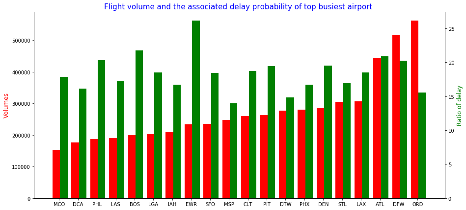

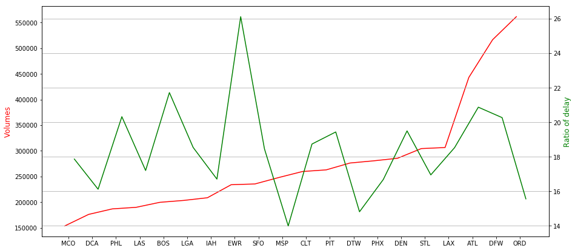

```python
# Note: df_airport in this case was created by data of "src_airport" union with "dest_airport" columns
# in the source dataset (Question 3.4).
# for analyzing the delayed flights on the top 20 busiest airports, create a new dataframe which
# adding the column 'is_delayed' to the 'airport' dataframe.The 'df_airport' is first filtered with
# 'top_busiest_airport_location'. The 'is_delayed' is then computed using the data of "arrival_delay"
# column. The value of the 'is_delayed' column will be 1 (delayed) if the arrival delay is more than
# 15 minutes and 0 in others cases.
df_with_delay = df_airport[df_airport.airport.isin(top_busiest_airport_location)].withColumn('is_delayed', func.when((df["arrival_delay"] >= 15), 1).otherwise(0))

# query percentage of delayed flights for the top 20 busiest airports via 3 steps:
# 1. groupBy: group the dataframe by 'airport'
# 2. agg: compute percentage of delayed flights over the total of fights for each group
# 3. orderBy: sort the result by 'ratio_of_delay' values
delay_ratio_of_top_busiest_airport = df_with_delay.groupBy('airport')\
                                                  .agg((100*func.sum('is_delayed')/func.count('*'))\
                                                  .alias('ratio_of_delay')).orderBy('ratio_of_delay')

# adding the flight volume to the previous result using 'join'
top_busiest_airport = airport.join(delay_ratio_of_top_busiest_airport, on='airport').select('*').orderBy('count')

# show the flight volume and the associated delay probability of each airport in the top 20 busiest airports
top_busiest_airport.show()

# plot (bar chart) the flight volume and the associated delay probability of each airport in the top 20 busiest airports
top_busiest_airport = top_busiest_airport.collect()
fig = plt.figure(figsize=(15,7))
fig.add_subplot(111)
plt.bar([x for x in range(len(top_busiest_airport))], [x[1] for x in top_busiest_airport], width = 0.4, color = 'r')
plt.ylabel("Volumes", color='r', size=12)
plt.twinx()
plt.bar([x + 0.4 for x in range(len(top_busiest_airport))], [x[2] for x in top_busiest_airport], width = 0.4, color = 'g')
plt.ylabel("Ratio of delay", color='g', size=12)
plt.xticks([x+0.15 for x in range(len(top_busiest_airport))], [x[0] for x in top_busiest_airport])
plt.title("Flight volume and the associated delay probability of top busiest airport ",fontsize=12,color='b', size=15)
plt.show()

# plot (line chart) the flight volume and the associated delay probability of each airport in the top 20 busiest airports
fig = plt.figure(figsize=(15,7))
fig.add_subplot(111)
plt.plot([x for x in range(len(top_busiest_airport))], [x[1] for x in top_busiest_airport], color = 'r')
plt.ylabel("Volumes", color='r', size=12)
plt.twinx()
plt.plot([x + 0.4 for x in range(len(top_busiest_airport))], [x[2] for x in top_busiest_airport], color = 'g')
plt.ylabel("Ratio of delay", color='g', size=12)
plt.xticks([x+0.15 for x in range(len(top_busiest_airport))], [x[0] for x in top_busiest_airport])
plt.grid()
plt.show()
```

### Question 4.7

What is the percentage of delayed flights which belong to one of the top 20 busiest carriers? Comment the figure!

SUGGESTION

You can try with different chart type to have a better visualization.

```
+-------+------+------------------+
|carrier| count|    ratio_of_delay|
+-------+------+------------------+
|     AS|117475|15.964247712279208|
|     HP|177851|18.625141269939444|
|     TW|258205|18.212273193780135|
|     NW|482798| 12.94806523639286|
|     CO|484834| 19.55576547849367|
|     WN|565426|12.829795587751535|
|     UA|638750|16.865283757338553|
|     AA|722277| 17.52444006939166|
|     US|857906|18.422298014001534|
|     DL|874526|18.328443065157582|
+-------+------+------------------+
```

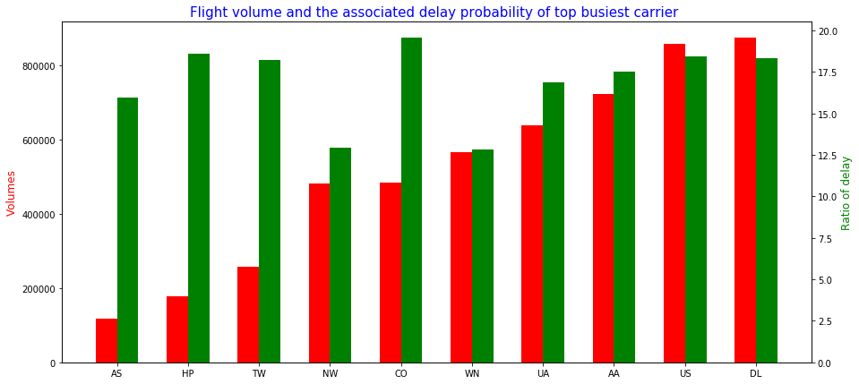

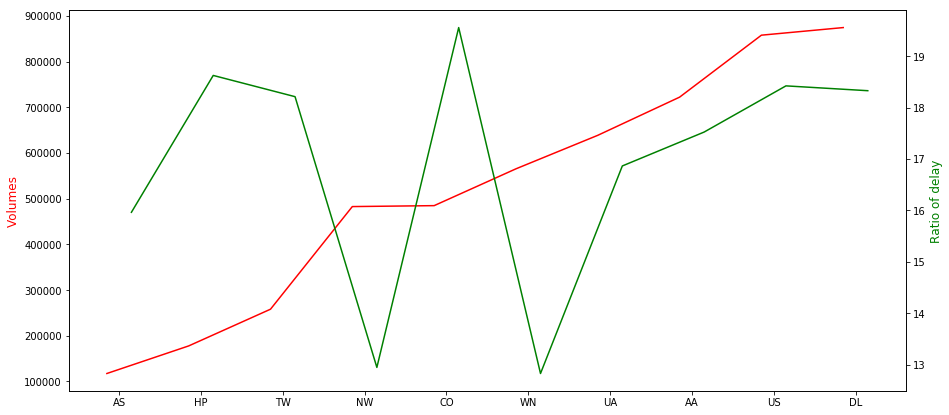

```python
# for analyzing the delayed flights on the top 20 busiest carrier, create a new dataframe which
# adding the column 'is_delayed' to the 'airport' dataframe.The 'df_airport' is first filtered with
# 'top_busiest_carrier_location'. The 'is_delayed' is then computed using the data of "arrival_delay"
# column. The value of the 'is_delayed' column will be 1 (delayed) if the arrival delay is more than
# 15 minutes and 0 in others cases.
df_with_delay = df[df.carrier.isin(top_busiest_carrier_location)].withColumn('is_delayed', func.when((df["arrival_delay"] >= 15), 1).otherwise(0))

# query percentage of delayed flights for the top 20 busiest carriers via 3 steps:
# 1. groupBy: group the dataframe by 'carrier'
# 2. agg: compute percentage of delayed flights over the total of fights for each group
# 3. orderBy: sort the result by 'ratio_of_delay' values
delay_ratio_of_top_busiest_carrier = df_with_delay.groupBy('carrier')\
                                                  .agg((100*func.sum('is_delayed')/func.count('*'))\
                                                  .alias('ratio_of_delay')).orderBy('ratio_of_delay')

# adding the flight volume to the previous result using 'join'
top_busiest_carrier = carriers.join(delay_ratio_of_top_busiest_carrier, on='carrier').select('*').orderBy('count')

# show the flight volume and the associated delay probability of each carrier in the top 20 busiest carriers
top_busiest_carrier.show()

# plot (bar chart) the flight volume and the associated delay probability of each carrier in the top 20 busiest carriers
top_busiest_carrier = top_busiest_carrier.collect()
fig = plt.figure(figsize=(15,7))
fig.add_subplot(111)
plt.bar([x for x in range(len(top_busiest_carrier))], [x[1] for x in top_busiest_carrier], width = 0.3, color = 'r')
plt.ylabel("Volumes", color='r', size=12)
plt.twinx()
plt.bar([x + 0.3 for x in range(len(top_busiest_carrier))], [x[2] for x in top_busiest_carrier], width = 0.3, color = 'g')
plt.ylabel("Ratio of delay", color='g', size=12)
plt.xticks([x+0.15 for x in range(len(top_busiest_carrier))], [x[0] for x in top_busiest_carrier])
plt.title("Flight volume and the associated delay probability of top busiest carrier ",fontsize=12,color='b', size=15)
plt.show()

# plot (line chart) the flight volume and the associated delay probability of each carrier in the top 20 busiest carriers
fig = plt.figure(figsize=(15,7))
fig.add_subplot(111)
plt.plot([x for x in range(len(top_busiest_carrier))], [x[1] for x in top_busiest_carrier], color = 'r')
plt.ylabel("Volumes", color='r', size=12)
plt.twinx()
plt.plot([x + 0.3 for x in range(len(top_busiest_carrier))], [x[2] for x in top_busiest_carrier], color = 'g')
plt.ylabel("Ratio of delay", color='g', size=12)
plt.xticks([x+0.15 for x in range(len(top_busiest_carrier))], [x[0] for x in top_busiest_carrier])
plt.show()
```